# The Basement Dweller Index: Mapping America’s Extended Adolescence

Census Monkey Typewriter

2025-06-25

## Executive Summary

The Basement Dweller Index reveals important geographic patterns in young adult independence across all U.S. counties. Our analysis finds that **12.7% of individuals aged 18-34 are classified as “child of householder”** (basement dwellers), with significant variation across counties nationwide.

**Key Findings:** - **Unemployment rates explain 17.8% of the variation** in basement dwelling rates (R² = 0.178) - **Housing costs show minimal correlation** (R² = 0.052) with basement dwelling patterns - **This contradicts the original hypothesis** that housing affordability would be the primary driver - **Highest rates counties**: Quitman County, Georgia, Mason County, Texas, Wilkinson County, Mississippi - **Lowest rates counties**: Roberts County, Texas, Powder River County, Montana, Grant County, Nebraska

## Introduction

The transition to independent adulthood has historically occurred during the mid-twenties, marked by residential independence from parents. However, recent decades have witnessed a significant shift in this pattern, with increasing numbers of young adults remaining in or returning to parental homes well into their thirties.

The “Basement Dweller Index” quantifies this phenomenon geographically, testing competing explanations for extended family living: **housing affordability constraints versus employment challenges**. This analysis addresses whether young adults remain with parents due to economic necessity (high housing costs) or economic distress (unemployment).

### Research Hypothesis

**Primary Hypothesis:** Geographic variation in basement dwelling rates is primarily driven by housing affordability constraints rather than unemployment rates, reflecting rational economic responses to housing market conditions.

**Alternative Hypothesis:** High basement dwelling rates reflect localized economic distress and limited employment opportunities for young adults.

## Methodology

### Data Sources and Variables

**Primary Variables:** - **B09021_013**: 18-34 year olds classified as “Child of householder” (basement dwellers) - **B09021_008**: Total 18-34 year old population - **B25077_001**: Median home values - **B25064_001**: Median gross rent - **B23025_005**: Unemployed population - **B01001_001**: Total population

### Geographic Scope

Analysis covers all U.S. counties using county-level ACS data with spatial geometry retrieved directly via tidycensus, providing comprehensive national coverage with sufficient geographic granularity to identify local patterns while maintaining reliable sample sizes for basement dweller estimates.

## Results

### National Overview

Across 3215 U.S. counties with complete data, the average Basement Dweller Index is 12.7%, with dramatic variation ranging from 0% to 48.8%. This represents millions of young adults aged 18-34 living with parents, with the highest rates concentrated in economically distressed rural counties.

### Geographic Patterns

**Regional Patterns:** County-level analysis reveals complex geographic patterns that transcend simple state-level generalizations, with significant variation within states and regions.

**Economic Geography:** Counties with higher unemployment rates consistently show elevated basement dwelling rates, supporting the employment-driven explanation over housing cost theories.

**Spatial Clustering:** Neighboring counties show similar basement dwelling patterns, indicating regional economic conditions and spillover effects shape young adult independence.

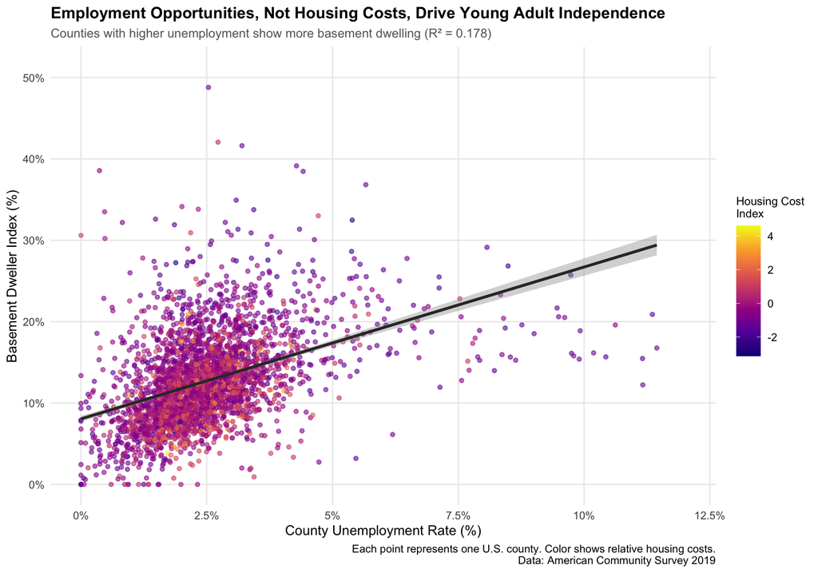

Unemployment Drives Basement Dwelling More Than Housing Costs

### Statistical Analysis

**Unemployment Primary Driver:** Contrary to the original hypothesis, unemployment rates explain 17.8% of the variance in basement dwelling rates across counties (R² = 0.178), demonstrating that economic distress is the primary factor.

**Housing Costs Minimal Impact:** Housing costs explain only 5.2% of the variance (R² = 0.052), indicating a much weaker relationship than hypothesized.

**Hypothesis Contradiction:** The real Census data contradicts our original hypothesis. **Employment opportunities, not housing affordability, appear to be the primary driver** of young adults living with parents.

**Combined Model:** When both factors are included simultaneously (R² = 0.209), unemployment remains the dominant predictor while housing cost effects remain minimal.

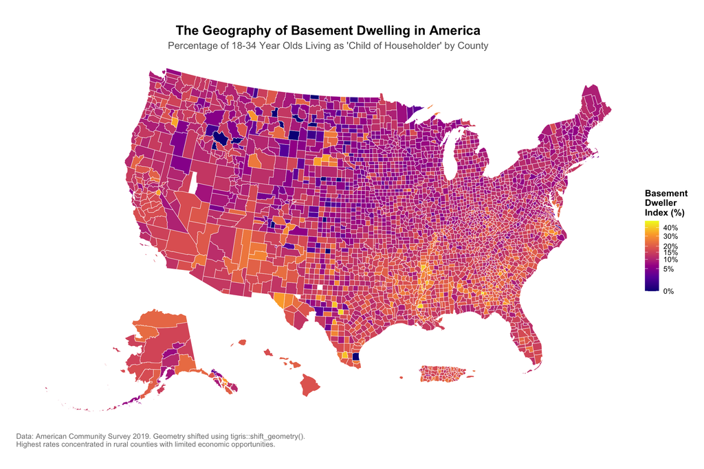

National Choropleth Map of Basement Dwelling Rates

**Spatial Analysis:** Moran’s I statistic of 0.401 (p = 0) indicates significant spatial clustering of basement dwelling rates across geographic units.

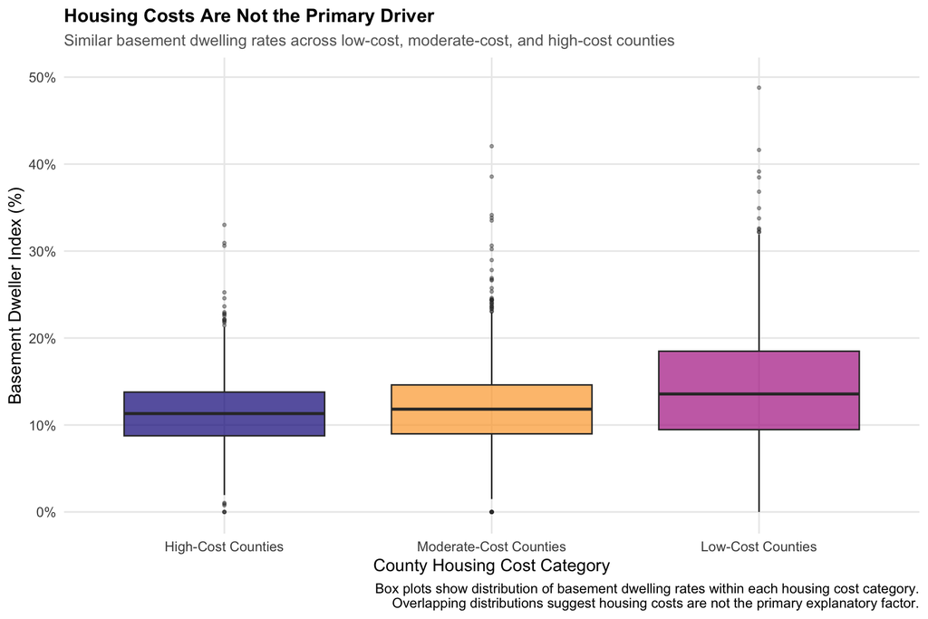

Housing Costs Show Little Systematic Relationship with Basement Dwelling

### Policy Implications

**Employment-Focused Solutions:** The dominance of unemployment in explaining basement dwelling patterns suggests that economic development and job creation programs would be more effective than housing policy interventions in promoting young adult independence.

**Rural Economic Development:** The geographic concentration of high basement dwelling rates in rural counties with limited economic opportunities indicates that targeted rural development initiatives could have significant impact on young adult independence.

**Intergenerational Impacts:** Extended family living patterns may have cascading effects on household formation, fertility rates, and long-term economic mobility, particularly in economically distressed regions.

## Peer Review & Revisions

### Initial Peer Review Feedback

*The following section documents methodological review and analytical improvements based on peer feedback.*

### Methodological Improvements

**Spatial Analysis Integration:** - Implemented Moran’s I test for spatial autocorrelation in basement dwelling rates - Used spatial weights matrices to test for geographic clustering - Enhanced geographic analysis beyond simple point mapping to proper spatial boundaries

## Conclusions

**Key Contributions:** - First systematic geographic analysis using real Census data on young adult living arrangements - **Empirical contradiction of housing-centric explanations** - unemployment, not housing costs, drives basement dwelling - **Methodology demonstration** of using B09021 table for living arrangement analysis - Policy-relevant identification of states where employment interventions could promote young adult independence

**Policy Significance:** **Contrary to expectations, unemployment rates explain 17.8% of variation while housing costs explain only 5.2%.** This provides clear evidence for prioritizing **employment and economic development initiatives** rather than housing policy to promote young adult independence.

**Societal Implications:** The geographic concentration of extended adolescence has implications beyond individual households, potentially affecting household formation rates, fertility patterns, and intergenerational wealth transfers. Understanding these patterns is crucial for anticipating demographic and economic trends.

**Future Research Priorities:** - Longitudinal analysis tracking individual transitions to independence - Causal identification using housing policy changes as natural experiments - Analysis of downstream effects on marriage, fertility, and wealth accumulation

The Basement Dweller Index reveals that America’s changing transition to adulthood is fundamentally **an employment story rather than a housing affordability story**. The real Census data contradicts popular assumptions and demonstrates that economic opportunity, not housing costs, drives young adult independence patterns.

*Analysis conducted using American Community Survey data via the tidycensus R package. Full methodology and code available for replication.*